# Projekt finalny ML

Natalia Misiaszek, Tomasz Martyński

2025-12-16

# Wczytanie danych i wstępna analiza

W naszym projekcie zajmiemy się problemem klasyfikacji danych. Zbiór, którym się posługujemy zawiera dane dotyczące alertu trzęsienia ziemi w zależności od 5 cech takich jak: - wielkość(magnitude) w skali Richtera, - głębokość (depth)- dległość od powierzchni Ziemi do punktu, w którym rozpoczyna się pękanie, - cdi-maksymalną zgłoszoną intensywność trzęsienia ziemi w danym zakresie, - mmi- maksymalną szacowaną intensywność trzęsienia ziemi zmierzoną przyrządami, - sig - kompleksowy wskaźnik znaczenia trzęsienia ziemi, określany na podstawie wielu czynników, w tym magnitudy, maksymalnej intensywności odczuwalnej (MMI), zgłoszeń od osób, które odczuły wstrząsy, oraz szacowanego wpływu. Wyższe wartości oznaczają bardziej istotne zdarzenia sejsmiczne.

Naszym celem będzie zatem budowa modelu, który na podstawie danych treningowych nauczy się przewidywać kolor alertu dla danych parametrów ze zbioru testowego. Porównamy drzewo decyzyjne, las losowy, k-NN oraz naiwny klasyfikator Bayesowski i sprawdzimy, która z tych metod najlepiej przewiduje kolor alertu trzęsienia ziemi.

Do precyzyjnej oceny poszczególnych modeli wykorzystamy macierz pomyłek, a w niektórych przypadkach, m.in porównanie normalizacji i standaryzacji Z-score, szczególnie istotna będzie dla nas dokładność (accuracy). Pojawia się naturalne pytanie, czy możemy korzystać z tej metryki, gdyż nie zawsze jest ona trafnym wyborem. W naszym przypadku możemy się na niej opierać, ponieważ zarówno zbiór treningowy, jak i testowy są zbalansowane pod względem rozkładu klas, a co za tym idzie dokładność w sposób rzetelny odzwierciedla ogólną skuteczność modeli i nie faworyzuje żadnej z klas.

```r
data= read.csv("/Users/misiaszekn/Downloads/earthquake_alert_balanced_dataset.csv")
data$alert <- factor(data$alert, levels = c("green", "yellow", "orange", "red"))
print(summary(data))
```

```
##    magnitude         depth             cdi             mmi
##  Min.   :6.500   Min.   :  2.00   Min.   :0.000   Min.   :1.000
##  1st Qu.:6.700   1st Qu.: 12.00   1st Qu.:6.000   1st Qu.:6.000
##  Median :7.000   Median : 19.00   Median :8.000   Median :7.000
##  Mean   :7.061   Mean   : 50.32   Mean   :6.976   Mean   :6.939
##  3rd Qu.:7.300   3rd Qu.: 38.00   3rd Qu.:8.000   3rd Qu.:8.000
##  Max.   :8.600   Max.   :670.00   Max.   :9.000   Max.   :9.000
##       sig              alert
##  Min.   :-128.000   green :325
##  1st Qu.: -54.000   yellow:325
##  Median :  -7.000   orange:325
##  Mean   :  -9.749   red   :325
##  3rd Qu.:  31.000
##  Max.   : 127.000
```

```r
print(table(data$alert))
```

```
##
##  green yellow orange    red
##    325    325    325    325
```

Tak jak wspomnieliśmy powyżej, zauważamy teraz dokładnie, że klasy są zrównoważone, a co za tym idzie nasz model nie będzie miał potencjalnie tendencji do faworyzowania jednej z nich. To dobra prognoza. Przejdźmy do przygotowania danych, podziału na zbiór treningowy i testowy.

# Przygotowanie danych

Dzięki poleceniu summary sprawdziliśmy już, że nie ma wartości NA. Zobaczmy zatem, czy są duplikaty, które mogłyby zaburzyć proces trenownia naszegomodelu.

## 1. Duplikaty

```r
library(dplyr)
print(paste("Liczba duplikatów w zbiorze danych:", sum(duplicated(data))))
```

```
## [1] "Liczba duplikatów w zbiorze danych: 44"
```

```r
data_cleaned= distinct(data)
print(paste("Liczba duplikatów w nowym zbiorze danych:", sum(duplicated(data_cleaned))))
```

```
## [1] "Liczba duplikatów w nowym zbiorze danych: 0"
```

## 2. Outliersy

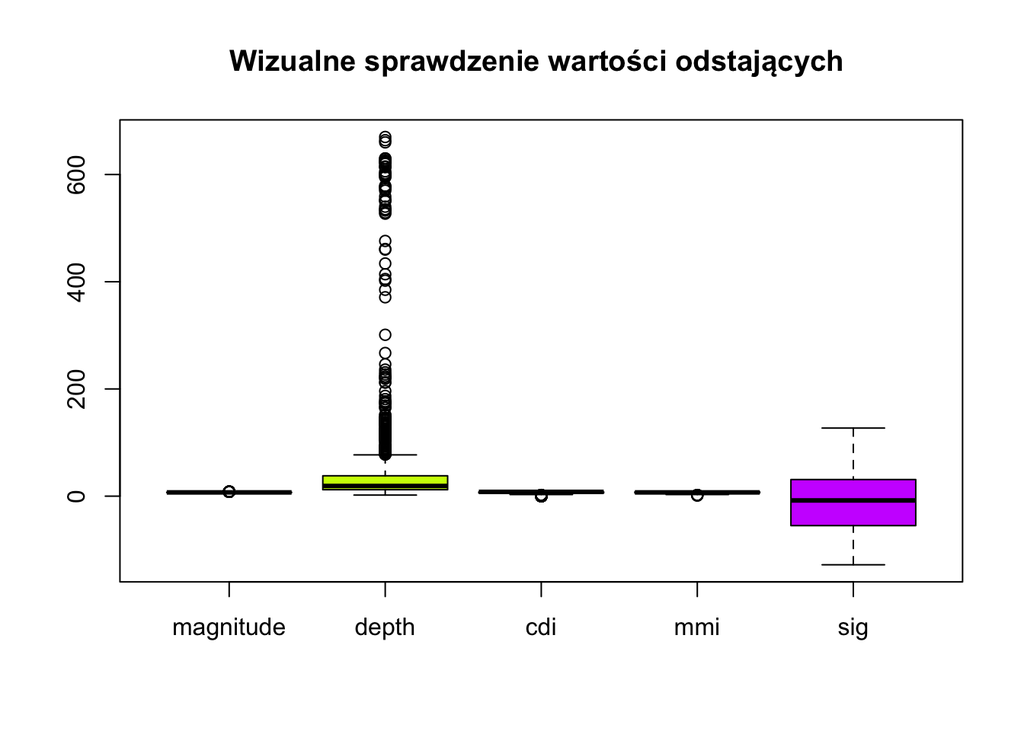

```r
numeric_columns= data_cleaned[sapply(data_cleaned, is.numeric)]


boxplot(numeric_columns, main = "Wizualne sprawdzenie wartości odstających ",
col= rainbow(ncol(numeric_columns))
)
```

```r
numeric_columns_names= names( data_cleaned[sapply(data_cleaned, is.numeric)])

for (col in numeric_columns_names) {
  x <- data_cleaned[[col]]

  Q1 <- quantile(x, 0.25, na.rm = TRUE)
  Q3 <- quantile(x, 0.75, na.rm = TRUE)
  IQR_val <- Q3 - Q1

  outliers <- data_cleaned[x < (Q1 - 1.5 * IQR_val) | x > (Q3 + 1.5 * IQR_val), ]

  cat(col, ": ", nrow(outliers), " outliers\n")
}
```

```
## magnitude :  21  outliers
## depth :  166  outliers
## cdi :  85  outliers
## mmi :  5  outliers
## sig :  0  outliers
```

## 3. Podział na zbiór testowy i treningowy

Aby mieć pewność, że dane do zbioru treningowego i testowego dobrane są w sposób losowy, użyjemy funkcji sample do wyboru próbek. Dane podzielimy w proporcji 80:20.

```r
set.seed(123)
sample_train= sample(nrow(data_cleaned), size= 0.8* nrow(data_cleaned))

data_train= data_cleaned[sample_train, ]
data_test= data_cleaned[-sample_train,]

prop.table(table(data_train$alert))
```

```
##
##     green    yellow    orange       red
## 0.2569721 0.2519920 0.2549801 0.2360558
```

```r
prop.table(table(data_test$alert))
```

```
##
##     green    yellow    orange       red
## 0.2539683 0.2579365 0.2380952 0.2500000
```

Proporcje danych są bardzo podobne w zbiorze treningowym i testowym, zatem możemy zostawić tak przyjęte zbiory.

# Budowa modeli

## Drzewo decyzyjne z algorytmem C5.0

### Budowa modelu

```r
library(C50)
model_dt= C5.0(data_train[-6], data_train$alert)
```

### Predykcja danych

```r
predict_dt=predict(model_dt, data_test[-6])
```

### Macierz pomyłek

```r
library(caret)
conf_mat_dt= confusionMatrix(predict_dt, data_test$alert)
conf_mat_dt
```

```
## Confusion Matrix and Statistics
##
##           Reference
## Prediction green yellow orange red
##     green     48      2      1   1
##     yellow    12     60      5   4
##     orange     3      3     53   2
##     red        1      0      1  56
##
## Overall Statistics
##
##                Accuracy : 0.8611
##                  95% CI : (0.8122, 0.9013)
##     No Information Rate : 0.2579
##     P-Value [Acc > NIR] : < 2e-16
##
##                   Kappa : 0.8147
##
##  Mcnemar's Test P-Value : 0.04342
##
## Statistics by Class:
##
##                      Class: green Class: yellow Class: orange Class: red
## Sensitivity                0.7500        0.9231        0.8833     0.8889
## Specificity                0.9787        0.8877        0.9583     0.9894
## Pos Pred Value             0.9231        0.7407        0.8689     0.9655
## Neg Pred Value             0.9200        0.9708        0.9634     0.9639
## Prevalence                 0.2540        0.2579        0.2381     0.2500
## Detection Rate             0.1905        0.2381        0.2103     0.2222
## Detection Prevalence       0.2063        0.3214        0.2421     0.2302
## Balanced Accuracy          0.8644        0.9054        0.9208     0.9392
```

### Wnioski

Ogólna dokładność modelu wynosi około 86%, co wskazuje na dobrą jakość klasyfikacji. Najistotniejszym przypadkiem z punktu widzenia analizowanego problemu są czerwone alerty, odpowiadające sytuacjom największego zagrożenia. Model poprawnie rozpoznaje 56 z 63 takich przypadków (czułość ≈ 0,89), jednak 7 obserwacji zostało błędnie sklasyfikowanych, co oznacza potencjalnie kosztowne przeoczenia krytycznych zdarzeń. W przypadku klas pomarańczowej i żółtej model osiąga stabilne wyniki, zarówno pod względem czułości, jak i precyzji. Najwięcej trudności sprawia klasa zielona, dla której poprawnie sklasyfikowano jedynie 48 z 64 obserwacji (czułość ≈ 0,75), co wskazuje na tendencję modelu do nadmiernego eskalowania poziomu alertów.

Sprawdźmy jenak, czy metodą Adaboost będziemy w stanie nieco polepszyć otrzymane wyniki.

## AdaBoost

### Budowa modelu

```r
model_dt_ab= C5.0(data_train[-6], data_train$alert, trials= 10)
```

### Predykcja danych

```r
predict_dt_ab=predict(model_dt_ab, data_test[-6])
```

### Macierz pomyłek

```r
conf_mat_dt_ab= confusionMatrix(predict_dt_ab, data_test$alert)
conf_mat_dt_ab
```

```
## Confusion Matrix and Statistics
##
##           Reference
## Prediction green yellow orange red
##     green     48      1      1   0
##     yellow    13     58      4   1
##     orange     2      4     54   3
##     red        1      2      1  59
##
## Overall Statistics
##
##                Accuracy : 0.869
##                  95% CI : (0.821, 0.9081)
##     No Information Rate : 0.2579
##     P-Value [Acc > NIR] : <2e-16
##
##                   Kappa : 0.8253
##
##  Mcnemar's Test P-Value : 0.0438
##
## Statistics by Class:
##
##                      Class: green Class: yellow Class: orange Class: red
## Sensitivity                0.7500        0.8923        0.9000     0.9365
## Specificity                0.9894        0.9037        0.9531     0.9788
## Pos Pred Value             0.9600        0.7632        0.8571     0.9365
## Neg Pred Value             0.9208        0.9602        0.9683     0.9788
## Prevalence                 0.2540        0.2579        0.2381     0.2500
## Detection Rate             0.1905        0.2302        0.2143     0.2341
## Detection Prevalence       0.1984        0.3016        0.2500     0.2500
## Balanced Accuracy          0.8697        0.8980        0.9266     0.9577
```

### Wnioski

Po zastosowaniu boostingu zauważamy, że rodzaj najbardziej kosztownego dla nas błędu jest mniejszy z tej perspektywy, iż model nie nazywa już żadnego czerwonego alertu zielonym, a te 3 z 4 źle sklasyfikowanych czerwonych alertów zalicza do pomarańczowych, zatem możemy to określić jako “mniejsze zło”. W przypadku pozostałych klas sytuacja się nie zmieniła i model nadal ma tendencję do nadmiernego eskalowania poziomu alertów.

## Macierz kosztów

W funkcji C5.0 możliwym argumentem jest również macierz kosztów. Spróbujmy stworzyć takową, z ustalonymi przez nas przykładowymi kosztami błędów i sprawdźmy, czy otrzymamy lepszy model.

```r
matrix_dimensions= list(c("green", "yellow", "orange", "red"),c("green", "yellow", "orange", "red"))
names(matrix_dimensions)= c("actual", "predicted")

cost_mat_dt <- matrix(
  c(0, 1, 2, 3,
    2, 0, 1, 2,
    5, 3, 0, 1,
    10, 7, 4, 0),
  nrow = 4,
  byrow = TRUE, dimnames = matrix_dimensions
)
cost_mat_dt= t(cost_mat_dt)
cost_mat_dt
```

```
##          actual
## predicted green yellow orange red
##    green      0      2      5  10
##    yellow     1      0      3   7
##    orange     2      1      0   4
##    red        3      2      1   0
```

### Budowa modelu

```r
model_cost_dt= C5.0(data_train[-6], data_train$alert, costs= cost_mat_dt)
```

### Predykcja danych

```r
predict_cost_dt=predict(model_cost_dt, data_test[-6])
```

### Macierz pomyłek

```r
conf_mat_dt_cost= confusionMatrix(predict_cost_dt, data_test$alert)
conf_mat_dt_cost
```

```
## Confusion Matrix and Statistics
##
##           Reference
## Prediction green yellow orange red
##     green     48      2      1   1
##     yellow    11     59      4   3
##     orange     4      4     54   4
##     red        1      0      1  55
##
## Overall Statistics
##
##                Accuracy : 0.8571
##                  95% CI : (0.8078, 0.8979)
##     No Information Rate : 0.2579
##     P-Value [Acc > NIR] : <2e-16
##
##                   Kappa : 0.8095
##
##  Mcnemar's Test P-Value : 0.0458
##
## Statistics by Class:
##
##                      Class: green Class: yellow Class: orange Class: red
## Sensitivity                0.7500        0.9077        0.9000     0.8730
## Specificity                0.9787        0.9037        0.9375     0.9894
## Pos Pred Value             0.9231        0.7662        0.8182     0.9649
## Neg Pred Value             0.9200        0.9657        0.9677     0.9590
## Prevalence                 0.2540        0.2579        0.2381     0.2500
## Detection Rate             0.1905        0.2341        0.2143     0.2183
## Detection Prevalence       0.2063        0.3056        0.2619     0.2262
## Balanced Accuracy          0.8644        0.9057        0.9187     0.9312
```

### Wnioski

Zauważamy, że sytuacja wygląda bardzo podobnie jak w przypadku drzewa decyzyjnego bez boostingu. Zatem z trzech rozważanych przez nas wersji zdecydowanie boosting daje nam najlepszy efekt.

## Random Forest

Inną z metod uczenia zespołowego jest las losowy. Podobnie jak koncepcja Adaboost działa na bazie określonej liczby słabych klasyfikatorów, np. drzew decyzyjnych, jednak opiera się na równoległym ich działaniu, a nie jak w przypadku Adaboost, sekwencji. Spróbujmy zastosować tą mtodę i określić, czy w ogólności nasz model ma wyższą jakość, niż w przypadkach poprzednich.

Uwaga: Możnaby próbować ulepszać model w podobny sposób jak to ma miejsce poniżej przy k-NN, to znaczy manewrować hiperparametrami. W tym przypadku bardziej skuteczna jest jednak walidacja krzyżowa, bądź odpowiednie funkcje z pakietu caret. Na potrzeby naszego projektu skupimy się bardziej na genezie i budowie lasu losowego z przyjętymi konkretnymi paramterami, a niżeli ręcznej ich estymacji.

### Budowa modelu

```r
library(randomForest)
model_rf= randomForest(alert~., data= data_train, ntree= 100, mtry=2, importance= TRUE)
```

### Predykcja danych

```r
model_rf_predict= predict(model_rf, data_test)
```

### Macierz pomyłek

```r
conf_mat_rf <- confusionMatrix(model_rf_predict, data_test$alert)
conf_mat_rf
```

```
## Confusion Matrix and Statistics
##
##           Reference
## Prediction green yellow orange red
##     green     51      0      0   0
##     yellow     9     63      1   1
##     orange     4      2     58   4
##     red        0      0      1  58
##
## Overall Statistics
##
##                Accuracy : 0.9127
##                  95% CI : (0.8708, 0.9445)
##     No Information Rate : 0.2579
##     P-Value [Acc > NIR] : < 2.2e-16
##
##                   Kappa : 0.8836
##
##  Mcnemar's Test P-Value : NA
##
## Statistics by Class:
##
##                      Class: green Class: yellow Class: orange Class: red
## Sensitivity                0.7969        0.9692        0.9667     0.9206
## Specificity                1.0000        0.9412        0.9479     0.9947
## Pos Pred Value             1.0000        0.8514        0.8529     0.9831
## Neg Pred Value             0.9353        0.9888        0.9891     0.9741
## Prevalence                 0.2540        0.2579        0.2381     0.2500
## Detection Rate             0.2024        0.2500        0.2302     0.2302
## Detection Prevalence       0.2024        0.2937        0.2698     0.2341
## Balanced Accuracy          0.8984        0.9552        0.9573     0.9577
```

### Wnioski

Random Forest dobrze klasyfikuje wszystkie klasy, szczególnie krytyczne czerwone alerty, które są najważniejsze. Pojawiło się dużo więcej zer. Mianowicie najgorszych przypadków, w których realne zagrożenie mylone jest z alertem zielonym, w każdej kategorii jest 0, a to już bardzo dobry wynik.

Najwięcej pomyłek pojawia się w klasie zielonej, ale są to błędy „sąsiednie”, a nie katastrofalne i nadal jest to najlepszy wynik w porównaniu z rozważanymi wcześniej modelami.

Ogólna dokładność jest wysoka, a model jest bezpieczny pod względem kosztownych błędów. Ponadto tendencja modelu do nadmiernego eskalowania poziomu alertów jest znacznie mniejsza, czyniąc go jak do tej pory najlepszym dla nas rozwiązaniem.

## Metoda k-NN

Jak wspomnieliśmy na początku, w tej metodzie niezbędnym będzie przeskalowanie danych do pewnego zakresu. Wykorzystamy technikę normalizacji min-max i sprowadzimy dane do wartości z przedziału [0,1].

Dlaczego normalizujemy dane już po podziale na zbiór testowy i treningowy? Odpowiedź jest oczywista - aby nie doprowadzić do wycieku danych - dane testowe nie mogą w jakikolwiek sposób wpływać na treningowe.

### Normalizacja danych

```r
normalize<-function(x){
  return((x-min(x))/(max(x)-min(x)))
}

data_train_knn=as.data.frame(lapply(data_train[-6], normalize))
data_test_knn=as.data.frame(lapply(data_test[-6], normalize))

summary(data_test_knn)
```

```
##    magnitude          depth              cdi              mmi
##  Min.   :0.0000   Min.   :0.00000   Min.   :0.0000   Min.   :0.0000
##  1st Qu.:0.1372   1st Qu.:0.01497   1st Qu.:0.6667   1st Qu.:0.7143
##  Median :0.3077   Median :0.02545   Median :0.8889   Median :0.7143
##  Mean   :0.3133   Mean   :0.08108   Mean   :0.7716   Mean   :0.7018
##  3rd Qu.:0.4436   3rd Qu.:0.05389   3rd Qu.:0.8889   3rd Qu.:0.8571
##  Max.   :1.0000   Max.   :1.00000   Max.   :1.0000   Max.   :1.0000
##       sig
##  Min.   :0.0000
##  1st Qu.:0.3083
##  Median :0.4708
##  Mean   :0.4570
##  3rd Qu.:0.6250
##  Max.   :1.0000
```

### Liczba sąsiadów

```r
wiersze= nrow(data_train)
wiersze
```

```
## [1] 1004
```

Jako parametr $k$ wybieramy najbliższą pierwiastkowi z 1004 liczbę nieparzystą $-->$ $k=31$.

### Budowa modelu

```r
library(class)
data_train_labels=data_cleaned[sample_train,6]
data_test_labels=data_cleaned[-sample_train,6]
knn_model= knn(data_train_knn, data_test_knn, data_train_labels, k=31)
```

### Macierz pomyłek

```r
conf_mat_knn <- confusionMatrix(knn_model, data_test_labels)
conf_mat_knn
```

```
## Confusion Matrix and Statistics
##
##           Reference
## Prediction green yellow orange red
##     green     42      2      0   0
##     yellow    15     42      5   0
##     orange     5     13     43   6
##     red        2      8     12  57
##
## Overall Statistics
##
##                Accuracy : 0.7302
##                  95% CI : (0.6709, 0.7839)
##     No Information Rate : 0.2579
##     P-Value [Acc > NIR] : < 2.2e-16
##
##                   Kappa : 0.6405
##
##  Mcnemar's Test P-Value : 3.162e-05
##
## Statistics by Class:
##
##                      Class: green Class: yellow Class: orange Class: red
## Sensitivity                0.6562        0.6462        0.7167     0.9048
## Specificity                0.9894        0.8930        0.8750     0.8836
## Pos Pred Value             0.9545        0.6774        0.6418     0.7215
## Neg Pred Value             0.8942        0.8789        0.9081     0.9653
## Prevalence                 0.2540        0.2579        0.2381     0.2500
## Detection Rate             0.1667        0.1667        0.1706     0.2262
## Detection Prevalence       0.1746        0.2460        0.2659     0.3135
## Balanced Accuracy          0.8228        0.7696        0.7958     0.8942
```

### Wnioski

Osiągnięta dokładność modelu wynosi około 73%. Analiza macierzy pomyłek pokazuje, że model skutecznie unika błędów fałszywie negatywnych w najgroźniejszych przypadkach. W szczególności trzęsienia ziemi o najwyższym poziomie zagrożenia („red”) nie są klasyfikowane jako zdarzenia niegroźne („green” lub „yellow”), a przypadki oznaczone jako „orange” nie otrzymują etykiety „green”.

Jest to pożądane zachowanie modelu, ponieważ koszt niedoszacowania zagrożenia jest znacznie wyższy niż koszt fałszywego alarmu. W praktyce lepiej wywołać niepotrzebną panikę niż zignorować realne niebezpieczeństwo, które może prowadzić do tragicznych konsekwencji. W całym zbiorze testowym model zaniżył poziom zagrożenia jedynie 13 razy, przy czym w każdym z tych przypadków różnica wynosiła dokładnie jedną klasę. Oznacza to, że nawet błędne predykcje pozostają relatywnie blisko rzeczywistego poziomu zagrożenia.

W dalszej części analizy sprawdzimy, jak zmiana wartości parametru $k$ wpływa na dokładność i charakter błędów modelu.

### Dopracowanie modelu- manewrowanie parametrem $k$

```r
k_values <- seq(1, 31, by = 2)
accuracy_values <- numeric(length(k_values))

for (i in seq_along(k_values)) {
  k <- k_values[i]

  knn_pred <- knn(
    train = data_train_knn,
    test  = data_test_knn,
    cl    = data_train_labels,
    k     = k
  )

  cm <- confusionMatrix(knn_pred, data_test_labels)
  accuracy_values[i] <- cm$overall["Accuracy"]
}
accuracy_values
```

```
##  [1] 0.8809524 0.8650794 0.8174603 0.8253968 0.8095238 0.7817460 0.7698413
##  [8] 0.7658730 0.7698413 0.7658730 0.7539683 0.7420635 0.7420635 0.7380952
## [15] 0.7261905 0.7261905
```

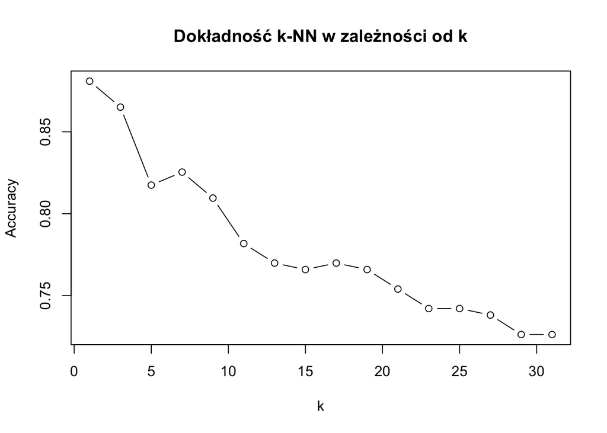

```r
plot(
  k_values,
  accuracy_values,
  type = "b",
  xlab = "k",
  ylab = "Accuracy",
  main = "Dokładność k-NN w zależności od k"
)
```

Wyniki wskazują, że mniejsze wartości parametru $k$ prowadzą do wyższej skuteczności modelu k-NN. Jednakże bardzo małe $k$ (1,3,5) w zestawieniu z dużą próbką danych, które posiadamy sugerują, że ich przewaga wynika prawdopodobnie z przeuczenia. Dlatego w drodze kompromisu wybierzmy $k=7$, które zachowuje wysoką dokładność przy jednoczesnym ograniczeniu liczby kosztownych błędów. Oczywiście w przypadku jakiegokolwiek wyboru parametru $k$, należałoby sprawdzić, czy model się nie przeucza. W naszej analizie jednak istotna jest generalna jego jakość, a nie to jak on dokładnie powstawał.

```r
knn_7_model=knn(data_train_knn, data_test_knn, data_train_labels, 7)
conf_mat_knn_7 <- confusionMatrix(knn_7_model, data_test_labels)
conf_mat_knn_7
```

```
## Confusion Matrix and Statistics
##
##           Reference
## Prediction green yellow orange red
##     green     44      4      0   0
##     yellow    12     56      4   1
##     orange     5      5     48   5
##     red        3      0      8  57
##
## Overall Statistics
##
##                Accuracy : 0.8135
##                  95% CI : (0.7598, 0.8596)
##     No Information Rate : 0.2579
##     P-Value [Acc > NIR] : < 2e-16
##
##                   Kappa : 0.7513
##
##  Mcnemar's Test P-Value : 0.03191
##
## Statistics by Class:
##
##                      Class: green Class: yellow Class: orange Class: red
## Sensitivity                0.6875        0.8615        0.8000     0.9048
## Specificity                0.9787        0.9091        0.9219     0.9418
## Pos Pred Value             0.9167        0.7671        0.7619     0.8382
## Neg Pred Value             0.9020        0.9497        0.9365     0.9674
## Prevalence                 0.2540        0.2579        0.2381     0.2500
## Detection Rate             0.1746        0.2222        0.1905     0.2262
## Detection Prevalence       0.1905        0.2897        0.2500     0.2698
## Balanced Accuracy          0.8331        0.8853        0.8609     0.9233
```

Model k-NN z $k=7$ jest lepszy niż z $k=31$, osiąga stabilną skuteczność, przy czym najgroźniejsze przypadki („red”) rzadko są klasyfikowane błędnie. Większość pomyłek dotyczy klas sąsiadujących („orange” ↔︎ „yellow”), co jest mniej kosztowne niż przeoczenie realnego zagrożenia. Klasa „green” bywa czasem przewidziana jako „yellow”, co odzwierciedla zachowawczy charakter modelu. Ogólnie stanowi dobry kompromis między dokładnością a ograniczeniem kosztownych błędów.

### Dopracowanie modelu- metoda z-score

Spróbujmy jeszcze standaryzacji z-score (od razu sprawdzimy dokładność dla różnych $k$). Chociaż z reguły nie powinniśmy się sugerować tylko accuracy, chcemy mieć wstępny pogląd na to czy z-score wypada “lepiej”, czy gorzej w porównaniu do min-max.

```r
data_train_knn_z=as.data.frame(scale(data_train[-6]))
data_test_knn_z=as.data.frame(scale(data_test[-6]))

k_values <- seq(1, 31, by = 2)
accuracy_values <- numeric(length(k_values))

for (i in seq_along(k_values)) {
  k <- k_values[i]

  knn_pred <- knn(
    train = data_train_knn_z,
    test  = data_test_knn_z,
    cl    = data_train_labels,
    k     = k
  )

  cm <- confusionMatrix(knn_pred, data_test_labels)
  accuracy_values[i] <- cm$overall["Accuracy"]
}
accuracy_values
```

```
##  [1] 0.8333333 0.8293651 0.7936508 0.7857143 0.7857143 0.7817460 0.7738095
##  [8] 0.7460317 0.7222222 0.7261905 0.7261905 0.7222222 0.7142857 0.7142857
## [15] 0.7142857 0.7063492
```

Na ogół zauważamy, że dokładność jest niższa niż w przypadku normalizacji - sprawdźmy jeszcze dokładnie przypadki dla $k=7$ oraz $k=31$.

```r
knn_modelz_7=knn(data_train_knn_z, data_test_knn_z, data_train_labels,7)
conf_mat_knnz_7 <- confusionMatrix(knn_modelz_7, data_test_labels)
conf_mat_knnz_7
```

```
## Confusion Matrix and Statistics
##
##           Reference
## Prediction green yellow orange red
##     green     44      1      0   0
##     yellow    12     53      6   1
##     orange     5     10     46   8
##     red        3      1      8  54
##
## Overall Statistics
##
##                Accuracy : 0.7817
##                  95% CI : (0.7256, 0.8311)
##     No Information Rate : 0.2579
##     P-Value [Acc > NIR] : < 2.2e-16
##
##                   Kappa : 0.7091
##
##  Mcnemar's Test P-Value : 0.005508
##
## Statistics by Class:
##
##                      Class: green Class: yellow Class: orange Class: red
## Sensitivity                0.6875        0.8154        0.7667     0.8571
## Specificity                0.9947        0.8984        0.8802     0.9365
## Pos Pred Value             0.9778        0.7361        0.6667     0.8182
## Neg Pred Value             0.9034        0.9333        0.9235     0.9516
## Prevalence                 0.2540        0.2579        0.2381     0.2500
## Detection Rate             0.1746        0.2103        0.1825     0.2143
## Detection Prevalence       0.1786        0.2857        0.2738     0.2619
## Balanced Accuracy          0.8411        0.8569        0.8234     0.8968
```

```r
knn_modelz_31=knn(data_train_knn_z, data_test_knn_z, data_train_labels,31)
conf_mat_knnz_31 <- confusionMatrix(knn_modelz_31, data_test_labels)
conf_mat_knnz_31
```

```
## Confusion Matrix and Statistics
##
##           Reference
## Prediction green yellow orange red
##     green     41      1      0   0
##     yellow    13     40      5   0
##     orange     6     14     40   6
##     red        4     10     15  57
##
## Overall Statistics
##
##                Accuracy : 0.7063
##                  95% CI : (0.6459, 0.7618)
##     No Information Rate : 0.2579
##     P-Value [Acc > NIR] : < 2.2e-16
##
##                   Kappa : 0.6088
##
##  Mcnemar's Test P-Value : 9.356e-07
##
## Statistics by Class:
##
##                      Class: green Class: yellow Class: orange Class: red
## Sensitivity                0.6406        0.6154        0.6667     0.9048
## Specificity                0.9947        0.9037        0.8646     0.8466
## Pos Pred Value             0.9762        0.6897        0.6061     0.6628
## Neg Pred Value             0.8905        0.8711        0.8925     0.9639
## Prevalence                 0.2540        0.2579        0.2381     0.2500
## Detection Rate             0.1627        0.1587        0.1587     0.2262
## Detection Prevalence       0.1667        0.2302        0.2619     0.3413
## Balanced Accuracy          0.8177        0.7596        0.7656     0.8757
```

Oceniając generalny feedback ze zbioru testowego standaryzacja z-score wypada słabiej niż normalizacja. Modele w tym przypadku częściej popełniają najgorsze w skutkach błędy, czyli zaniżanie poziomu zagrożenia.

### Wnioski

W metodzie k-NN, najlepszy okazuje się być model dla $k=7$ z znormalizowanymi danymi. Warto podkreślić również, że tym podejściu dobieramy wartość $k$ w sposób ręczny, porównując dokładność modeli dla różnych $k$ na zbiorze testowym. Jest to prosta estymacja, pozwalająca wybrać kompromis między skutecznością a ryzykiem błędów fałszywie negatywnych, bez stosowania formalnej walidacji krzyżowej.

## Naiwny estymator Bayesowski

NB świetnie działa na danych kategorycznych. Możemy zaimplementować go również w przypadku danych ilościowych, jednak należy pamiętać o konsekwencjach za tym idących. Mianowicie, jeżeli sami poprzez binning ( dyskretyzacje) nie skategoryzujemy zmiennych ilościowych, NB przyjmie dla nich rozkład normalny w danej klasie, co w konsekwencji może doprowadzić do złych estymacji prawdopodobieństw, a to z kolei może doprowadzić do niskiej jakości modelu.

Z binngiem również należy uważać. Wykonując dyskretyzację, poniekąd tracimy pewną informację o danych. Źle dobrane przedziały mogą pogorszyć model, np zbyt dużo przedziałów= problem z estymacją.

Rozważymy obie sytuacje, zarówno z jak i bez binningu. Sprawdzimy, czy cechy są warunkowo niezależne i jak rozkładają się ich wartości w danej klasie. Ostatecznie ocenimy, w którym przypadku model będzie “lepszy”.

### Niezależność cech

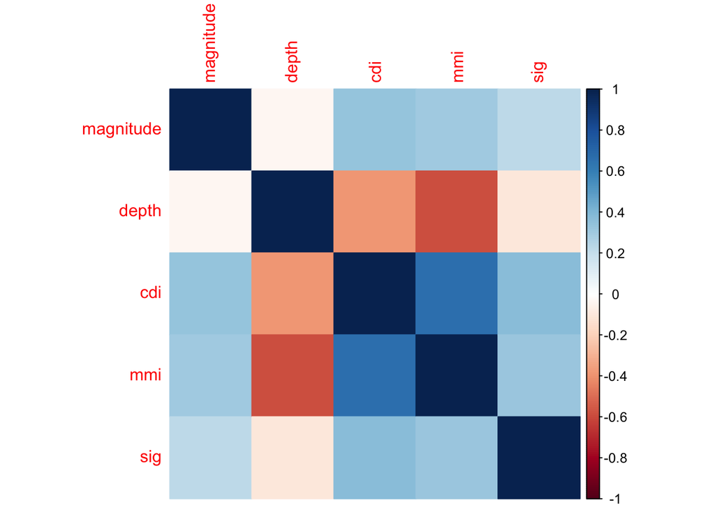

```r
library(corrplot)
corrplot(cor(data_train[-6]), method = "color")
```

**Wnioski**: Widać, że zazwyczaj brak między cechami tendencji do korelacji, jednak pojawiają się wyjątki - ciemniejsze niebieskie (poza przekątną) i czerwone bloki. Nie są to jednak sytuacje krytyczne. Co więcej wiemy, iż pomimo naruszenia założenia niezależności cech, NB często działa dobrze w praktyce, ponieważ w klasyfikacji liczy się tylko porządek prawdopodobieństw między klasami, a nie ich dokładna wartość. Możemy się zatem spodziewać co najwyżej lekkiego przeszacowania prawdopodobieństw.

### Rozkłady zmiennych ilościowych

Jak już wspomnieliśmy w przypadku, gdy nie dyskretyzujemy cech ilościowych, NB sam radzi sobie z nimi przyjmując “naiwnie”, iż mają one rozkład normalny w danej klasie. Oczywistym jest, że nie zawsze musi to być prawda. Sprawdźmy wizualnie zatem, jak wyglądają te rozkłady dla poszczególnych klas.

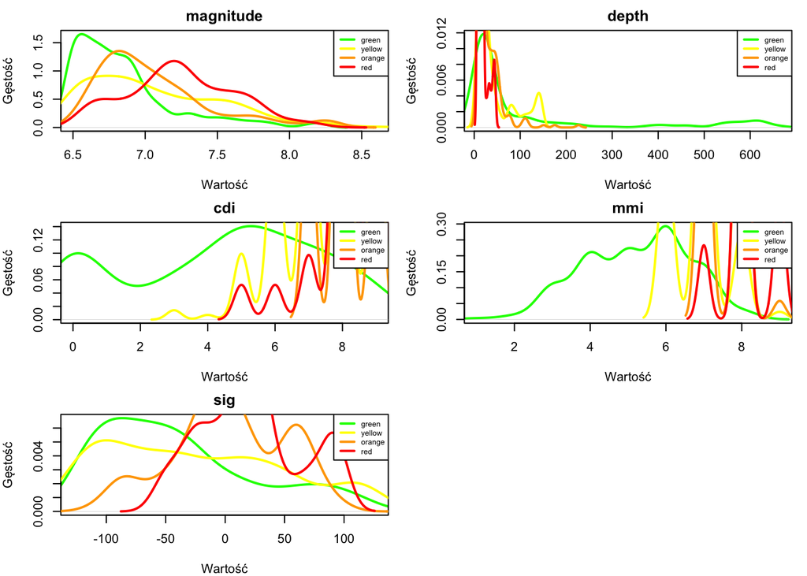

```r
classes <- c("green","yellow","orange","red")
colors <- c("green","yellow","orange","red")

cechy <- c("magnitude","depth","cdi","mmi","sig")

par(mfrow=c(3,2), mar=c(4,4,2,1))

for(feature in cechy){
  plot(density(data_train[[feature]][data_train$alert == classes[1]]),
       main = feature,
       xlab = "Wartość",
       ylab = "Gęstość",
       col = colors[1],
       lwd=2,
       xlim=range(data_train[[feature]]))

  for(i in 2:length(classes)){
    lines(density(data_train[[feature]][data_train$alert == classes[i]]),
          col = colors[i], lwd=2)
  }

  legend("topright", legend=classes, col=colors, lwd=2, cex=0.6)
}
```

Szybka wizualizacja gęstości rozkładów zmiennych ilościowych pozwala bez problemu stwierdzić, iż bez dyskretyzacji założenie NB o rozkładach normalnych dla poszczególnych cech w konkretnych klasach byłoby błędne, a co za tym idzie, ogólnie model mógłby dawać zły feedback.

### NB bez binningu

```r
library(e1071)
bayes=naiveBayes(data_train[-6], data_train_labels)
predict_bayes= predict(bayes, data_test[-6])
bayes_confusion= confusionMatrix(predict_bayes, data_test$alert)
bayes_confusion
```

```
## Confusion Matrix and Statistics
##
##           Reference
## Prediction green yellow orange red
##     green     44      5      3   0
##     yellow    14     34     11   4
##     orange     4     18     28   5
##     red        2      8     18  54
##
## Overall Statistics
##
##                Accuracy : 0.6349
##                  95% CI : (0.5722, 0.6944)
##     No Information Rate : 0.2579
##     P-Value [Acc > NIR] : < 2e-16
##
##                   Kappa : 0.5131
##
##  Mcnemar's Test P-Value : 0.01014
##
## Statistics by Class:
##
##                      Class: green Class: yellow Class: orange Class: red
## Sensitivity                0.6875        0.5231        0.4667     0.8571
## Specificity                0.9574        0.8449        0.8594     0.8519
## Pos Pred Value             0.8462        0.5397        0.5091     0.6585
## Neg Pred Value             0.9000        0.8360        0.8376     0.9471
## Prevalence                 0.2540        0.2579        0.2381     0.2500
## Detection Rate             0.1746        0.1349        0.1111     0.2143
## Detection Prevalence       0.2063        0.2500        0.2183     0.3254
## Balanced Accuracy          0.8225        0.6840        0.6630     0.8545
```

Tak jak zakładaliśmy, model wypada bardzo słabo. Dokładność na poziomie ok 64% jest jak do tej pory najniższym wynikiem, który udało nam się osiągnąć.

### NB z binningiem

Każdą cechę dyskretyzujemy poprzez podział na kwantyle, ponieważ nie dysponujemy ekspercką wiedzą dotyczącą struktury tych danych. Jest to rozsądne podejście domyślne, zgodne z metodami omawianymi na zajęciach, które nie wprowadza dodatkowych, nieuzasadnionych założeń dotyczących rozkładu zmiennych.

Funkcja quantile wyznacza granice kwantyli wyłącznie na podstawie danych ze zbioru treningowego (cuts), a następnie stosuje ten sam podział zarówno do zbioru treningowego, jak i testowego. Takie postępowanie zapobiega wyciekowi informacji ze zbioru testowego, ponieważ proces dyskretyzacji nie wykorzystuje danych, które powinny pozostać niewidoczne na etapie uczenia modelu.

```r
data_train_bayes= data_train[-6]
data_test_bayes= data_test[-6]
quantilize<-function(column){

  cuts <- quantile(data_train_bayes[[column]], probs = seq(0,1,length.out = 5), na.rm = TRUE)

  cuts <- unique(cuts)
  n_actual_bins <- length(cuts) - 1
  if(n_actual_bins < 1){
    n_actual_bins <- 1
    }

  labels_q <- paste0("Q", seq_len(n_actual_bins))

  column_train <- cut(data_train_bayes[[column]], breaks = cuts, include.lowest = TRUE,labels = labels_q)

  column_test <- cut(data_test_bayes[[column]], breaks = cuts, include.lowest = TRUE,labels = labels_q)

  return(list(train = column_train, test = column_test))
}
```

```r
data_train_bayes_disc<-data_train[-6]
data_test_bayes_disc<-data_test[-6]

cols=names(data_train[-6])

for(col in cols){
  q=quantilize(col)
  data_train_bayes_disc[[col]]<-q$train
  data_test_bayes_disc[[col]] <-q$test
}

summary(data_test_bayes_disc)
```

```
##  magnitude  depth    cdi      mmi      sig
##  Q1:54     Q1  :73   Q1: 64   Q1: 59   Q1:56
##  Q2:49     Q2  :54   Q2:142   Q2:102   Q2:67
##  Q3:78     Q3  :62   Q3: 46   Q3: 82   Q3:67
##  Q4:71     Q4  :61            Q4:  9   Q4:62
##            NA's: 2
```

```r
bayes_disc=naiveBayes(data_train_bayes_disc, data_train_labels)

bayes_disc_pred= predict(bayes_disc, data_test_bayes_disc)

bayes_disc_conf= confusionMatrix(bayes_disc_pred, data_test$alert)
bayes_disc_conf
```

```
## Confusion Matrix and Statistics
##
##           Reference
## Prediction green yellow orange red
##     green     46     14      0   0
##     yellow    11     31      8   8
##     orange     7     14     37   6
##     red        0      6     15  49
##
## Overall Statistics
##
##                Accuracy : 0.6468
##                  95% CI : (0.5844, 0.7058)
##     No Information Rate : 0.2579
##     P-Value [Acc > NIR] : < 2.2e-16
##
##                   Kappa : 0.5293
##
##  Mcnemar's Test P-Value : NA
##
## Statistics by Class:
##
##                      Class: green Class: yellow Class: orange Class: red
## Sensitivity                0.7188        0.4769        0.6167     0.7778
## Specificity                0.9255        0.8556        0.8594     0.8889
## Pos Pred Value             0.7667        0.5345        0.5781     0.7000
## Neg Pred Value             0.9062        0.8247        0.8777     0.9231
## Prevalence                 0.2540        0.2579        0.2381     0.2500
## Detection Rate             0.1825        0.1230        0.1468     0.1944
## Detection Prevalence       0.2381        0.2302        0.2540     0.2778
## Balanced Accuracy          0.8221        0.6663        0.7380     0.8333
```

Jak widzimy sytuacja nie uległa niestety drastycznej poprawie. Spróbujmy jeszcze regulować parametr Laplace’a. Być może to polepszy obecną sytuację.

### Manewrowanie parametrem Laplace’a

```r
laplace_values <- c(0, 1, 2, 3, 4,5,6,7,8)

results <- data.frame(Laplace = laplace_values, Accuracy = NA)

for(i in seq_along(laplace_values)){

  lap <- laplace_values[i]

  bayes_model <- naiveBayes(data_train_bayes_disc, data_train_labels, laplace = lap)

  pred <- predict(bayes_model, data_test_bayes_disc)

  cm <- confusionMatrix(pred, data_test$alert)

  results$Accuracy[i] <- cm$overall["Accuracy"]
}

print(results)
```

```
##   Laplace  Accuracy
## 1       0 0.6468254
## 2       1 0.6468254
## 3       2 0.6468254
## 4       3 0.6468254
## 5       4 0.6468254
## 6       5 0.6468254
## 7       6 0.6468254
## 8       7 0.6428571
## 9       8 0.6428571
```

**Wnioski** Dla wartości parametru Laplace w zakresie od 0 do 6 dokładność modelu pozostaje taka sama, jak w przypadku poprzednim. Oznacza to, że nasz zbiór treningowy dostatecznie pokrywa wszystkie kategorie cech, więc nie napotykamy zerowych prawdopodobieństw. Dalsze zwiększanie wartości Laplace prowadzi do nieznacznego spadku dokładności, ponieważ nadmierne wygładzanie rozmywa naturalne rozkłady cech. W związku z tym nie ma potrzeby ustawiania wartości innej niż domyślna (0), co jest zgodne z intuicyjną interpretacją parametru.

Model naiwnego klasyfikatora bayesowskiego po zastosowaniu binningu daje skuteczność około $64.7\%$.

# Podsumowanie

```r
extract_metrics <- function(cm) {
  data.frame(
    Accuracy = as.numeric(cm$overall["Accuracy"]),
    stringsAsFactors = FALSE
  )
}
model_summary <- data.frame(
  Model = c(
    "Decision Tree (C5.0)",
    "Decision Tree + AdaBoost",
    "Decision Tree + Cost Matrix",
    "Random Forest",
    "k-NN (k=31, min-max)",
    "k-NN (k=7, min-max)",
    "k-NN (k=7, z-score)",
    "Naive Bayes (no binning)",
    "Naive Bayes (binning)"
  ),
  Accuracy = c(
    extract_metrics(conf_mat_dt)$Accuracy,
    extract_metrics(conf_mat_dt_ab)$Accuracy,
    extract_metrics(conf_mat_dt_cost)$Accuracy,
    extract_metrics(conf_mat_rf)$Accuracy,
    extract_metrics(conf_mat_knn)$Accuracy,
    extract_metrics(conf_mat_knn_7)$Accuracy,
    extract_metrics(conf_mat_knnz_7)$Accuracy,
    extract_metrics(bayes_confusion)$Accuracy,
    extract_metrics(bayes_disc_conf)$Accuracy
  )
)

model_summary
```

```
##                         Model  Accuracy
## 1        Decision Tree (C5.0) 0.8611111
## 2    Decision Tree + AdaBoost 0.8690476
## 3 Decision Tree + Cost Matrix 0.8571429
## 4               Random Forest 0.9126984
## 5        k-NN (k=31, min-max) 0.7301587
## 6         k-NN (k=7, min-max) 0.8134921
## 7         k-NN (k=7, z-score) 0.7817460
## 8    Naive Bayes (no binning) 0.6349206
## 9       Naive Bayes (binning) 0.6468254
```

Nawet bez ręcznej manipulacji hiperparametrami lasu losowego model ten wypada najlepiej spośród wszystkich przez nas rozważanych. Zaraz po nim znajduje się drzewo decyzyjne z boostingiem, stąd też wywnioskować możemy, że uczenie zespołowe dominuje nad pojedynczymi klasyfikatorami.